# Prediction Assignment Writeup

Author: Andrew D. Stewart  
Title: Prediction Assignment Write up  
10/26/2017

## Synopsis:

This analysis examines the data from accelerometers on the belt, forearm, arm, and dumbell of 6 participants. They were asked to perform barbell lifts correctly and incorrectly in 5 different ways. This project’s goal is to use the data from the sensors to train a model that can predict how well the activity was performed. An **interactive 3-D plot** and 2-D plots are provided to visualize the variable importance and classification of the Training Data set to the calculated prediction model.

Total Number of Words: 1,231  
Total Number of Figures: 5

### Data

The training data for this project are available here: https://d396qusza40orc.cloudfront.net/predmachlearn/pml-training.csv

The test data are available here: https://d396qusza40orc.cloudfront.net/predmachlearn/pml-testing.csv

The description of the data for this project come from this source: http://web.archive.org/web/20161224072740/http:/groupware.les.inf.puc-rio.br/har.

## What You Should Submit: (Quoted from Assignment)

1. You should create a report describing how you built your model,
2. how you used cross validation,
3. what you think the expected out of sample error is, and
4. why you made the choices you did.
5. You will also use your prediction model to predict 20 different test cases.

## Load Libraries and Set Defaults

This section loads R Libraries, sets knitr defaults for output, and sets a random seed (4891) to support reproducabilty. See markdown file for actual code.

## Question 1 - Model Build

### Part a - Loading and Preprocessing the Data

First the Training data for the model must be read in from the data sources identified above. Next, *all columns* of the data that contain sensor-subject summary data (kurtosis, skewness, max, min, amplitude, var, avg, stddev) are removed since the approach was to use only the actual sensor data (and remove NA data). The first seven (7) columns were also removed as they contain identifying information (e.g.: subject name) that were also not relevant for a model based only on sensor data.

Finally, the Training data was partitioned into two sets (70% / 30%) to support model development on the first set (70%) and *Cross Validation* on the second set (30%). Later, for the chosen Random Forest model, this was shown not to be necessary; but was insightful for understanding the model’s overvall performance.

```r
## Read activity.csv and format as tbl_df
actyTrainData <- read.csv("pml-training.csv", header = TRUE)
actyTrainData <- tbl_df(actyTrainData)

## Make a copy to use to partition
traindata <- tbl_df(actyTrainData)

## Read Column names
keepcolnames <-colnames(traindata)

## Create vector of column names to keep (remove summary statistic column names)
names_vector <- !(grepl("^(kurtosis)",keepcolnames) | grepl("^(skewness)",keepcolnames) | grepl("^(max)",keepcolnames) | grepl("^(min)",keepcolnames) | grepl("^(amplitude)",keepcolnames)| grepl("^(var)",keepcolnames) | grepl("^(avg)",keepcolnames) | grepl("^(stddev)",keepcolnames) )

## Select only column names with senor data
filtertraindata <- select(traindata,keepcolnames[names_vector])

## Remove first seven (7) columns of non-sensor data
filtertraindata <- select(filtertraindata,-c(1:7))

## Partition the Traing data into two Training sets for cross-validation
inTrain = createDataPartition(y=filtertraindata$classe, p = 0.7,list=FALSE)
training1 = filtertraindata[inTrain,]
training2 = filtertraindata[-inTrain,]
```

## Question 1 - Model Build

### Part b - Train the Model as Random Forest

The outcome variable is a classification variable (**classe**) with character values ‘A’ (perfect) through ‘E’ that represent the spectrum of how participants were directed to perform the exercise (see the link above for a detailed description of each classe). The sensor data from each of the 4 accelerators produces readings across yaw, pitch, and roll data; and gyro and acceleration in the x, y, and z directions – together, 52 columns of data, 1 column of results and 19,622 observations. Hence, there is a significant amount of data in the Training Set.

A basic classification tree `rpart` was initially used as an exploratory modeling approach; however, the basic classification tree results produced low accuracy results. Subsequently, modeling the data with a Random Forest produced superior results. Some experimentation with principle component analysis (PCA) was conducted; however, this did not produce any more accurate results than the Random Forest model which allows bootstrapping and voting across the many, many trees created by this robust modeling approach.

Although the Random Forest is computationally more expensive, the **Coursera Class Forum Notes** references provided the following github repo which showed a method on how to use parallel processing to enhance processing time: ## https://github.com/lgreski/datasciencectacontent/blob/master/markdown/pml-randomForestPerformance.md

```r
## Parallel Cluster Code from Class Forum/Discusson on methods using Parallel Processing:
## Class Forum notes references the following github repo:
## https://github.com/lgreski/datasciencectacontent/blob/master/markdown/pml-randomForestPerformance.md

## System Info:  Processor Name: Intel Core i7, Processor Speed:2.6 GHz, Number of Processors: 1, Total Number of Cores: 4, L2 Cache (per Core): 256 KB, L3 Cache: 6 MB, Memory: 16 GB

## Also, had to use: devtools::install_github('topepo/caret/pkg/caret') to update caret

## Set up Parallel Cluster  -- Allowing one (1) core for MAC-OS:
cluster <- makeCluster(detectCores() - 1)
registerDoParallel(cluster)

## Set Training Control Parameters:
fitControl <- trainControl(method = "oob",number = 10, allowParallel = TRUE)

## Fit Classe to all Sensor data:
fit2 <- train(classe ~. , method="rf",data=training1, trControl = fitControl, importance = TRUE)

## Stop parallel processing cluster
stopCluster(cluster)
registerDoSEQ()
```

## Question 2 - Perform Model Review and Cross Validation:

Again, Random Forest iteratively generates multiple random trees from the training data with replacement/bootstrapping and provides the miscalculation rate for each tree in order to vote for each tree. Hence, splitting the training set is not necessarily required for Cross Validation.

Nevertheless, since the Training Set data had already been partitioned (70% / 30%) from previous model exploration, another Cross Validation step was taken against the second Training Set Partition in order to validate the model’s results in advance on applying the model to the Test Data Set.

Comparing the confusion matrix for the first Training Set with the cross-validated results of the second Training Set produces similar results – which is expected from the Random Forest model which essentially cross-validates internally to the Training Set from which it is created by Bagging (Bootstrap Aggregating). These results reinforced the accuracy of and confidence in the model.

```r
## Model Review
## Compare 1st Training Set with Model Predictions
conMatrix <- confusionMatrix(training1$classe, fit2$finalModel$predicted)
print(conMatrix)
```

```
## Confusion Matrix and Statistics
##
##           Reference
## Prediction    A    B    C    D    E
##          A 3901    5    0    0    0
##          B   14 2637    6    1    0
##          C    0   19 2373    4    0
##          D    0    0   48 2201    3
##          E    0    0    5    5 2515
##
## Overall Statistics
##
##                Accuracy : 0.992
##                  95% CI : (0.9904, 0.9934)
##     No Information Rate : 0.285
##     P-Value [Acc > NIR] : < 2.2e-16
##
##                   Kappa : 0.9899
##  Mcnemar's Test P-Value : NA
##
## Statistics by Class:
##
##                      Class: A Class: B Class: C Class: D Class: E
## Sensitivity            0.9964   0.9910   0.9757   0.9955   0.9988
## Specificity            0.9995   0.9981   0.9980   0.9956   0.9991
## Pos Pred Value         0.9987   0.9921   0.9904   0.9774   0.9960
## Neg Pred Value         0.9986   0.9978   0.9948   0.9991   0.9997
## Prevalence             0.2850   0.1937   0.1770   0.1610   0.1833
## Detection Rate         0.2840   0.1920   0.1727   0.1602   0.1831
## Detection Prevalence   0.2843   0.1935   0.1744   0.1639   0.1838
## Balanced Accuracy      0.9980   0.9945   0.9869   0.9955   0.9990
```

```r
## Cross-Validate Model with 2nd Training Set:
predictTrain2 <- predict(fit2, newdata=training2)
conMatrix <- confusionMatrix(predictTrain2, training2$classe)
print(conMatrix)
```

```
## Confusion Matrix and Statistics
##
##           Reference
## Prediction    A    B    C    D    E
##          A 1673    1    0    0    0
##          B    0 1135    7    0    0
##          C    0    3 1017   20    0
##          D    0    0    2  944    2
##          E    1    0    0    0 1080
##
## Overall Statistics
##
##                Accuracy : 0.9939
##                  95% CI : (0.9915, 0.9957)
##     No Information Rate : 0.2845
##     P-Value [Acc > NIR] : < 2.2e-16
##
##                   Kappa : 0.9923
##  Mcnemar's Test P-Value : NA
##
## Statistics by Class:
##
##                      Class: A Class: B Class: C Class: D Class: E
## Sensitivity            0.9994   0.9965   0.9912   0.9793   0.9982
## Specificity            0.9998   0.9985   0.9953   0.9992   0.9998
## Pos Pred Value         0.9994   0.9939   0.9779   0.9958   0.9991
## Neg Pred Value         0.9998   0.9992   0.9981   0.9959   0.9996
## Prevalence             0.2845   0.1935   0.1743   0.1638   0.1839
## Detection Rate         0.2843   0.1929   0.1728   0.1604   0.1835
## Detection Prevalence   0.2845   0.1941   0.1767   0.1611   0.1837
## Balanced Accuracy      0.9996   0.9975   0.9932   0.9892   0.9990
```

## Question 3 - Expected Out of Sample Error

The Random Forest builds on the Training Set data with each randomly chosen tree being compared to approx. one-third of the data not used in that tree. This error is the Out Of Bag Error Estimate of that particular tree in the random forest. The misclassification rate, or out of bag (OOB) error rate, can be aggregated across all trees for the overall expected OOB error rate.

For this model, this is calculated from the mean of the chosen final model’s OOB error rate, which is: 1.23%. Note that this is approximately twice (1 - Accuracy) of the cross-validated 2nd Training Set. Again, this provides high-confidence for running the model against the Test Data.

```r
## Out Of Bag error estimates
mean(fit2$finalModel$err.rate[,"OOB"])
```

[1] 0.01233201

## Question 4 - Model Choice Review

### And, 2-D and 3-D Plots of the Training Data

Besides the overwhelmingly positive statistical and numerical results above, visual inspection of the data via graphs enforces the decision making process. The first plot (Variable Importance Plot) shows the variables that the top four variables are: roll_belt, yaw_belt, magnet_dumbbell_z, and pitch_belt for mean decrease in accuracy and Gini. After these four variables, the remainder “center and lower” variables both continue to play key importance in accuracy and Gini. Given that parallel processing allows for a *relatively* quick processing of the model and that previous principle component analysis did not improve model performance, this validated keeping all 52 variables/observations.

The next three plots show the clustering of the classe types for the four top-most influential variables. Model performance against classe ‘A’ and ‘E’ is not surprising given the the distinct grouping of these classes in these plots.

While 2-D plots are helpful, the last plot, a **3-D Interactive Plot**, provides even more insight when grouping classification across 3-axis. Note that this plot can be **moved/rotated and zoomed-in/out** to see different 3-d groupings and views. ‘E’ Classification becomes even more obvious and more tightly classifications of the other variables becomes easier to see – and underlines the need for additional variables to classify the more tightly grouped classes.

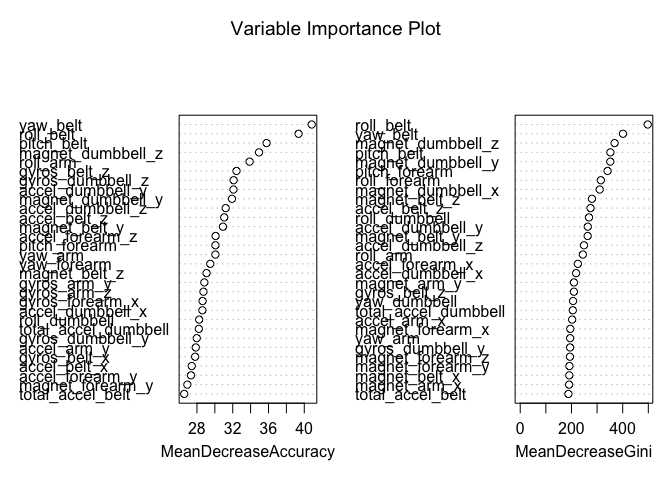

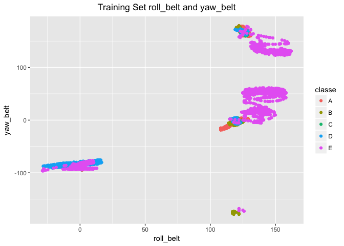

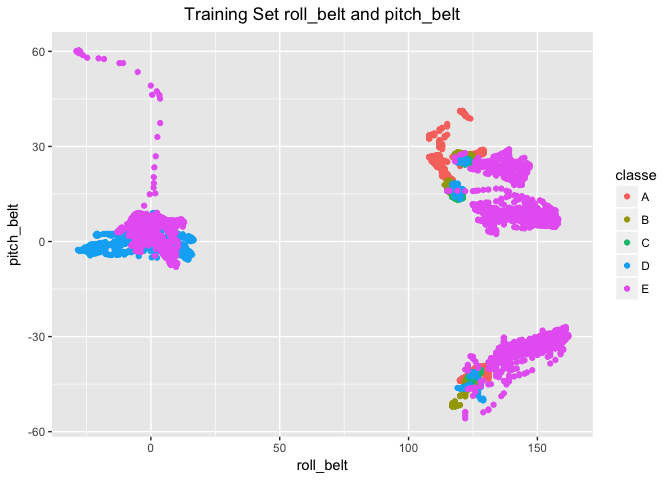

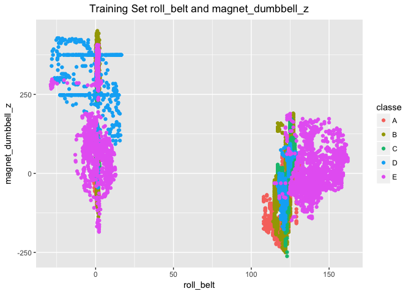

[interactive chart not shown]

## Question 5 - Model Prediction Against Test Set

The Test Set is read-in from the Data as identified above. The Test Data Set is filtered exactly as the Training Data Set was by removing the columns associated with summary statistical data (kurtosis, skewness, max, min, amplitude, var, avg, stddev) and removing the first seven (7) columns of data that do not contain sensor information. Each row of the data corresponds to the associated Quiz question number/observation.

Prediction on the Test Data Set is run by simply using the `predict` function and the model developed above. The results were submitted to the Quiz and produced **100% correct results**.

```r
## Read and Filter Test Data:
actyTestData <- read.csv("pml-testing.csv", header = TRUE)
actyTestData <- tbl_df(actyTestData)
testdata <- tbl_df(actyTestData)  ## Makes a copy

## Filter out columns to match Training Set
keepcolnamesT <-colnames(testdata)
names_vectorT <- !(grepl("^(kurtosis)",keepcolnamesT) | grepl("^(skewness)",keepcolnamesT) | grepl("^(max)",keepcolnamesT) | grepl("^(min)",keepcolnamesT) | grepl("^(amplitude)",keepcolnamesT)| grepl("^(var)",keepcolnamesT) | grepl("^(avg)",keepcolnamesT) | grepl("^(stddev)",keepcolnamesT) )

## Keep only Sensor Columns:
filtertestdata <- select(testdata,keepcolnamesT[names_vectorT])
filtertestdata <- select(filtertestdata,-c(1:7))

## Run Prediction on Test Set using model:
pred <- predict(fit2,filtertestdata)
pred <- tbl_df(pred)
pandoc.table(pred, style = "rmarkdown")
```

```
##
##
## | value |
## |:-----:|
## |   B   |
## |   A   |
## |   B   |
## |   A   |
## |   A   |
## |   E   |
## |   D   |
## |   B   |
## |   A   |
## |   A   |
## |   B   |
## |   C   |
## |   B   |
## |   A   |
## |   E   |
## |   E   |
## |   A   |
## |   B   |
## |   B   |
## |   B   |
```

```r
## Results Submitted to Quiz -- 100%!!
```

### This repo is located at:

https://adstewart91.github.io/practicalmachinelearning/Prediction_Assignment.html

https://htmlpreview.github.io/?https://adstewart91.github.io/practicalmachinelearning/Prediction_Assignment.html